# Exploration Relation Col&Mon

Olivier

17 octobre 2019

# 1 Statistiques descriptives des données

## 1.1 Chargement des données et prise en main

### 1.1.1 Chargement

```r
#implantation.dat <- readRDS("data/T0impl.Rds")
# fait.dat <- readRDS("data/T0New.Rds")
fait.dat <- read.csv("data/fait.txt", stringsAsFactors = FALSE) # besoin d'ajouter cela sinon il me garde tous les niveaux des facteurs
implantation.dat <- read.csv("data/implantation.txt")
# une exraction des relations
relation.dat <- fait.dat[fait.dat$caracNew == "Relations" ,]
```

Les données sont regroupées en deux tableaux :

- “T0impl.Rds” contenant les implantations,
- “T0New.Rds” contenant les faits.

C’est du second que l’on tire les relations.

### 1.1.2 Prise en main

```r
# l'encoding semble en UTF8 et latin1 en fonction des colonnes/sources de la données
# la fonction Encoding permet de le specifier
# Encoding(fait.dat$usual_name) <- "latin1"
# Encoding(fait.dat$caracteristique) <- "latin1"
# Encoding(fait.dat$linked_implantation_name) <- "latin1"
```

Il faut specifier les encoding de 3 colonnes qui sont en “Latin1” alors que le reste semble être en UTF8. Au final knitr semble avoir un problème avec du “multi encoding”, j’ai donc fait un export/import le tout en UTF8.

Le tableau 1.1 reprend les nombre de données manquantes par variables. L’absence la plus importante est sur les dates (210 et 206 manquantes), puis sur la localisation (72 NA) avec lat/long et granularité et sur les diocése (11 NA).

```r
# un apply, passer en df qui compte le nombre de NA par colonne
relation_na.dat <- as.data.frame(apply(relation.dat, 2, function(x)length(x[is.na(x)])))
names(relation_na.dat) <- "Nbr_NA" # on renome puis on fait une deuxième var qui prend les rowname
relation_na.dat$variables <- rownames(relation_na.dat)
rownames(relation_na.dat) <- NULL

# une bidouille pour avoir un titre de tableau avec ref
cat("<tableau>",paste0("<caption>", "(#tab:presenceNa)", ' Nombre de données manquantes par variabes', "</caption>"),"</tableau>", sep ="\n")
```

Table 1.1: Nombre de données manquantes par variabes

```r
DT::datatable(relation_na.dat)
```

|  | Nbr_NA | variables |
| --- | --- | --- |
| 1 | 0 | X |
| 2 | 0 | idfactoid |
| 3 | 0 | idimplantation |
| 4 | 0 | usual_name |
| 5 | 0 | caracteristique |
| 6 | 0 | caracNew |
| 7 | 0 | modAgreg |
| 8 | 0 | modalite |
| 9 | 0 | fklinked_implantation |
| 10 | 0 | linked_implantation_name |

[output cut: 11 more lines]

```r
#knitr::kable(apply(relation.dat, 2, function(x)length(x[is.na(x)]))) # la version à l'arrache knitr
```

## 1.2 Description des relations

### 1.2.1 Modalité des relations

On obtient 2564 factoides avec une `relation`. Le tableau 1.2 répartit `modalite` en fonction des `modAgreg`. `H` de `modAgreg` ne correspond qu’aux associations de prière (147)) et `X` ne correspond qu’aux déplacements d’institution (29). `A` et `D` correspondent aux relations ascendantes et descendantes comprises entre trois couples :

- `À la collation de / Droit de patronage`,
- `Appartient / à Possède` et
- `Filiation ascendante directe / Filiation descendante`.

```r
knitr::kable(t(table(relation.dat$modAgreg, relation.dat$modalite)),
             caption = "Ventilation de modAgreg en fonction de modalite")
```

Table 1.2: Ventilation de modAgreg en fonction de modalite

|  | A | D | H | X |
| --- | --- | --- | --- | --- |
| À la collation de | 171 | 0 | 0 | 0 |
| Appartient à | 199 | 0 | 0 | 0 |
| Association de prière | 0 | 0 | 147 | 0 |
| Déplacement d’institution | 0 | 0 | 0 | 29 |
| Droit de patronage | 0 | 171 | 0 | 0 |
| Filiation ascendante directe | 824 | 0 | 0 | 0 |
| Filiation descendante | 0 | 824 | 0 | 0 |
| Possède | 0 | 199 | 0 | 0 |

### 1.2.2 Modalités et relations dans le temps

#### 1.2.2.1 Exploration des données manquantes dans les dates

Il y a 210 et 206 valeurs manquantes au niveau des dates (cf. tableau 1.1). Ces valeurs manquantes sont consistantes dans les 6 champs de de description des dates : une absence de donnée en `date_start_XX` se retrouve en `date_stop_XX` et donc dans la fourchette produite.

Il y a cependant 4 exceptions, où l’on a une `date_stop`, correspondant à deux couples A/D :

```r
NA_date <- relation.dat[is.na(relation.dat$date_start_min),]
knitr::kable(NA_date[!is.na(NA_date$date_stop_max),c(2:4,7,13)]) # attention ici une indexation sur num de colonnes
```

|  | idfactoid | idimplantation | usual_name | modAgreg | date_stop_min |
| --- | --- | --- | --- | --- | --- |
| 12113 | 43491 | 2399 | Saint-Georges-en-Couzan, Saint-Georges (église dépendante) | A | 1790 |
| 12114 | 43492 | 1846 | Lyon, Saint-Nizier | D | 1790 |
| 12200 | 43578 | 2448 | Saint-Alban, Saint-Alban (église dépendante) | A | 1790 |
| 12242 | 43620 | 1646 | Cerdon, Saint-Jean-Baptiste | D | 1790 |

En regardant la répartition des valeurs manquantes temporelles en fonction de `modalite` (1.3) on peut remarquer qu’un couple A/D n’est pas complet (60/61).

```r
knitr::kable(table(NA_date$modalite), caption = "Répartition des NA temporelles dans les modalite")
```

Table 1.3: Répartition des NA temporelles dans les modalite

| Var1 | Freq |
| --- | --- |
| À la collation de | 60 |
| Appartient à | 19 |
| Association de prière | 47 |
| Droit de patronage | 61 |
| Filiation ascendante directe | 2 |
| Filiation descendante | 2 |
| Possède | 19 |

Il me semble que c’est ce couple, Hélene peux tu regarder ? Je rajoute les valeurs ?

```r
rbind(NA_date[NA_date$modAgreg == "D",][76,],
relation.dat[relation.dat$idimplantation == 2483,]) # attention c'est une indexation par rapport à un emplacement
```

```
##           X idfactoid idimplantation
## 12293 12293     43672           2131
## 12292 12292     43671           2483
##                                                        usual_name
## 12293                          Charleville-Mézières, Saint-Pierre
## 12292 Les-Mazures, Saint-Remi-Sainte-Gertrude (église dépendante)
##              caracteristique  caracNew modAgreg           modalite
## 12293 Relations - Dépendance Relations        D Droit de patronage
## 12292 Relations - Dépendance Relations        A  À la collation de
##       fklinked_implantation
## 12293                  2483
## 12292                  2131
##                                          linked_implantation_name
## 12293 Les-Mazures, Saint-Remi-Sainte-Gertrude (église dépendante)
## 12292                          Charleville-Mézières, Saint-Pierre
##       date_start_min date_start_max date_stop_min date_stop_max      lat
## 12293             NA             NA            NA            NA 49.76208
## 12292           1190           1190          1800          1800 49.88855
##            lng location_granularity Diocese date_startC date_stopC
## 12293 4.726096                  rue   Reims          NA         NA
## 12292 4.626041              precise   Reims        1190       1800
##       DureeFact
## 12293        NA
## 12292       610
```

On peut produire une carte rapide des valeurs manquantes pour les dates (promis j’en fait une belle semi-interactive sous mapview plus tard, je suis allez au plus vite ce vendredi après midi). On en a un gros cluster autour de la region lyonaise et un autre autour de Charleville-Mézières. Est ce que cela suit une logique par rapport au données ?

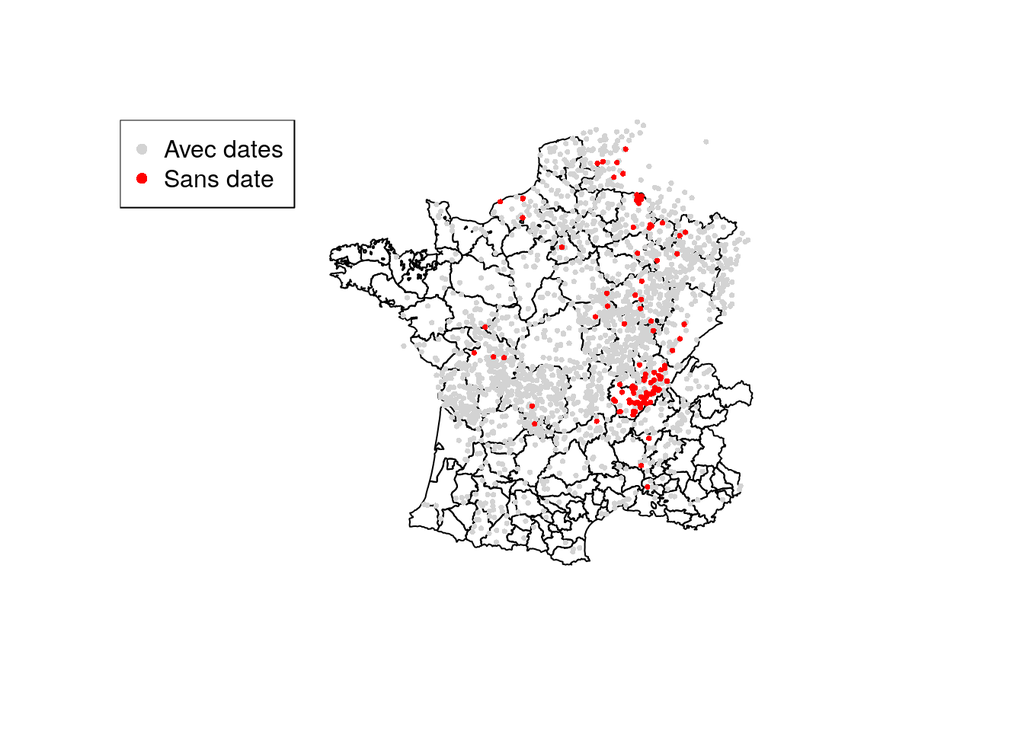

```r
plot(st_geometry(diocese.shp))
plot(st_geometry(implantation.shp), add =  T, col = "lightgrey", pch = 16, cex = .5)
plot(st_geometry(NA_date.shp), add = T, col = "red", pch = 16, cex = .5)
legend("topleft", legend=c("Avec dates", "Sans date"), pch = 16,
       col=c("lightgrey", "red"))
```

# 2 Premiers graphes sur les relations

## 2.1 En prenant le tout

```r
library(igraph)
relation <- relation.dat[relation.dat$modAgreg != "A",] # on enleve les doublons
# on ne garde que les noms
relation <- subset(relation, select =  c("usual_name", "linked_implantation_name"))
# objet de graphs
graph_ensemble <- graph.edgelist(as.matrix(relation), directed = FALSE)
```

Attention `igraph` masque et utilise des fonctions de `dplyr` et `base` comme `as_data_frame`, `groups`, `union`.

On obtient un graphe peut lisible avec 1370 liens et 1232 noeuds.